# Wasps vs Bees

Bienen sind unerlässlich für unser Ökosystem. In unserem Ökosystem sind Bienen zu 80% zum Bestäuben unsere Wild- und Nutzpflanzen verantwortlich. Allerdings sind Bienen auch vom Aussterben bedroht und gelten als besonders geschütztes Lebewesen. Wespen und Bienen kommen gerne aneinander. Angelockt vom Honig der Bienen versuchen diese in den Bienenstock einzudringen und dabei kommt es zu einem Kampf zwischen Bienen und Wespen, wobei eine Wespe einer Biene grundsätzlich überlegen ist. Als Imker ist es dabei wichtig, Bienen vor Wespen zu schützen. Dabei spielt die Erkennung von Wespen und rechtzeitige Maßnahmen eine große Rolle um die Bienenvölker zu schützen. Deep Learning würde sich hierbei anbieten, um Wespen frühzeitig zu Erkennen.

Hierfür wurde folgender Datensatz von Kaggle benutzt: Datensatz:

- https://www.kaggle.com/jerzydziewierz/bee-vs-wasp

Quellen:

- https://www.badenova.de/blog/bienen-und-ihre-umweltbedeutung/
- https://www.bund.net/themen/tiere-pflanzen/wildbienen/bedrohung-schutz/
- https://www.bussgeldkatalog.org/tierschutz-biene/

[figure not shown]

Bildquelle:

- https://www.gartenbau.org/magazin/unterschied-biene-wespe-201917314

## Imports

```python
import tensorflow as tf
import numpy as np
import pandas as pd
import sys
import seaborn as sns
import matplotlib.pyplot as plt
from matplotlib.colors import ListedColormap
from sklearn import metrics
import cv2
```

### Version- checks

```python
print("Python Version:", sys.version)
print("Tensorflow Version:", tf.__version__)
```

```
Python Version: 3.7.10 (default, Feb 26 2021, 13:06:18) [MSC v.1916 64 bit (AMD64)]
Tensorflow Version: 1.15.0
```

```python
tf.test.gpu_device_name()
```

```
'/device:GPU:0'
```

### Variablen deklarieren

```python
img_size = (64,64)
input_shape = (64,64,3)
seed = 1000
epochs = 100
patience = 10
color_mode = "rgb"
batch_size = 32
dir_path = "data/kaggle_bee_vs_wasp/"
```

## Hilfsfunktionen

```python
def get_Dataset(dir_path):
    df_label = pd.read_csv(dir_path + "labels.csv", index_col="id")

    print("Besitzen die Daten NaN-Werte?", df_label.isnull().values.any())

    df_label_train = df_label[(df_label["is_validation"] == 0) & (df_label["is_final_validation"] == 0)]
    df_label_val = df_label[(df_label["is_validation"] == 1)]
    df_label_test = df_label[(df_label["is_final_validation"] == 1)]

    return df_label_train, df_label_val, df_label_test
```

```python
def plot_dataframe_info(df_label_train, df_label_val, df_label_test):
    xaxislabels = ["train", "val", "test"]
    yaxislabels = ["datapoints", "is_bee", "is_wasp", "is_otherinsect", "is_other","photo_quality"]

    plot_lst = []

    plot_lst.append([
                        df_label_train.shape[0],
                        df_label_val.shape[0],
                        df_label_test.shape[0]
                        ])

    for yaxislabel in yaxislabels[1:]:
        plot_lst.append([
                        df_label_train[df_label_train[yaxislabel] == 1].shape[0],
                        df_label_val[df_label_val[yaxislabel] == 1].shape[0],
                        df_label_test[df_label_test[yaxislabel] == 1].shape[0]
                        ])

    plot_lst = np.array(plot_lst)

    N = 256
    vals = np.ones((N, 4))
    vals[:, 0] = np.linspace(90/256, 1, N)
    vals[:, 1] = np.linspace(90/256, 1, N)
    vals[:, 2] = np.linspace(90/256, 1, N)
    newcmp = ListedColormap(vals)

    plt.figure(figsize = (12, 10))
    p = sns.heatmap(plot_lst, annot=True, linewidths=.5, fmt="d", cbar = False, annot_kws={"fontsize":18}, vmin = -50000, vmax = 10000)
    p.set_yticklabels(yaxislabels, size = 16, rotation=0)
    p.set_xticklabels(xaxislabels, size = 16)

    plt.title("Informationen zu den Datensätzen\n", fontsize = 24)
```

```python
def plot_train_results(history):
    plt.figure(figsize = (16,10))

    plt.plot(np.linspace(1,len(history.history['acc']),len(history.history['acc'])),history.history['acc'],label="training acc")
    plt.plot(np.linspace(1,len(history.history['val_acc']),len(history.history['val_acc'])),history.history['val_acc'], label="validation_acc")
    plt.ylabel("Accuracy", fontsize=18)
    plt.xlabel("Epochen", fontsize=18)
    plt.title('Train/Val Acc', fontsize=24)
    plt.legend()

    plt.figure(figsize = (16,10))


    plt.plot(np.linspace(1,len(history.history['loss']),len(history.history['loss'])),history.history['loss'],label="training loss")
    plt.plot(np.linspace(1,len(history.history['val_loss']),len(history.history['val_loss'])),history.history['val_loss'], label="validation_loss")
    plt.ylabel("Loss", fontsize=18)
    plt.xlabel("Epochen", fontsize=18)
    plt.title('Train/Val Loss', fontsize=24)
    plt.legend()

    plt.show()
```

```python
def plot_results(y_true, results, modelname, plot_labels):
    y_pred = np.zeros_like(results)
    y_pred[np.arange(len(results)), results.argmax(1)] = 1

    y_pred = np.where(y_pred==1)
    y_pred = y_pred[1]

    mat = metrics.confusion_matrix(y_true, y_pred)
    cr = metrics.classification_report(y_true, y_pred,output_dict=True)

    cr_list = []
    for i in np.arange(0,4,1):
        tmp_list = []
        tmp_list.append(cr[str(i)]["precision"])
        tmp_list.append(cr[str(i)]["recall"])
        cr_list.append(tmp_list)

    cr_list = np.asarray(cr_list)

    plt.figure(figsize = (16, 7))

    ax = plt.subplot(1, 2, 1)
    p = sns.heatmap(mat, annot=True,fmt="d", linewidths=.5, cbar = False, annot_kws={"fontsize":14})
    p.set_yticklabels(plot_labels, size = 16, rotation = 0)
    p.set_xticklabels(plot_labels, size = 16)
    ax.set_xlabel("Vorhersage",fontsize=18)
    ax.set_ylabel("Ground Truth",fontsize=18)
    ax.set_title("Confusion Matrix "+modelname,fontsize=20)

    palette = sns.color_palette("coolwarm", as_cmap=False)
    palette.reverse()
    ax = plt.subplot(1, 2, 2)
    p = sns.heatmap(cr_list, annot=True, cbar = False, linewidths=.5, annot_kws={"fontsize":14})
    p.set_xticklabels(["Precision", "Recall"], size = 16)
    p.set_yticklabels(plot_labels, size = 0, rotation = 0)
    ax.set_title("Precision/Recall",fontsize=20)

    plt.tight_layout()
    plt.show()

def calc_cam(model, original_img):
    width, height, _ = original_img.shape
    inp = original_img.reshape(1, 64, 64, 3)

    results = model.predict(inp)
    y_pred = np.zeros_like(results)
    y_pred[np.arange(len(results)), results.argmax(1)] = 1

    y_pred = np.where(y_pred[0]==1)

    class_weights = model.layers[-1].get_weights()[0]

    cam_weights = class_weights[:,y_pred[0]]

    final_conv_layer = model.get_layer("conv2d_3")
    get_output = tf.keras.backend.function([model.layers[0].input],[final_conv_layer.output, model.layers[-1].output])
    [conv_outputs, predictions] = get_output([inp])
    conv_outputs = np.squeeze(conv_outputs)

    final_output = np.dot(conv_outputs, cam_weights)
    return final_output, original_img, y_pred


def visualize_class_activation_map(model, data, plot_labels):

    plt.figure(figsize=(16,10))

    final_output, original_img, y_pred = calc_cam(model, data[0][0])
    print("Vorhersage: ", plot_labels[y_pred[0][0]])
    ax = plt.subplot(1, 2, 1)
    ax.imshow(final_output)
    ax2 = plt.subplot(1, 2, 2)
    ax2.imshow(original_img)
    plt.show()

    plt.figure(figsize=(16,10))
    final_output, original_img, y_pred = calc_cam(model, data[0][1])
    print("Vorhersage: ", plot_labels[y_pred[0][0]])
    ax = plt.subplot(1, 2, 1)
    ax.imshow(final_output)
    ax2 = plt.subplot(1, 2, 2)
    ax2.imshow(original_img)
    plt.show()
```

## Laden des Datensatzes

Es wird zunächst der Datensatz geladen.

Anzahl der Datenpunkte pro Datensatz:

- Trainingsdatensatz: 7939
- Validierungsdatensatz: 1719
- Testdatensatz: 1763

Im abgebildeten Trainingsdatenframe sind die Spaltenbezeichnungen sichtbar.

| Spaltenname | Erläuterung | Wertebereich |
| --- | --- | --- |
| path | Gibt den Pfad zum Bild dieses Datenpunktes an | - |
| is_bee | Gibt an, ob es sich um eine Biene handelt | 1 = Biene \| 0 = Keine Biene |
| is_wasp | Gibt an, ob es sich um eine Wespe handelt | 1 = Wespe \| 0 = Keine Wespe |
| is_otherinsect | Gibt an, ob es sich um ein anderes Insekt handelt | 1 = Insekt \| 0 = Kein Insekt |
| is_other | Gibt an, ob es sich um ein willkürliches Foto handelt | 1 = willkürliches Foto \| 0 = kein willkürliches Foto |
| photo_quality | Gibt an, wie sicher das Label mit dem Bild übereinstimmt (Bei geringerer Bildqualität war sich der Ersteller des Datensatzes nicht sicher, was auf dem Bild ist) | 1 = Sicher \| 0 = Unsicher |
| is_validation | Gibt an, ob der Datenpunkt zum Validationsdatensatz gehört | 1 = Validationdatensatz \| 0 = gehört nicht zum Validationdatensatz |
| is_final_validation | Gibt an, ob der Datenpunkt zum Testdatensatz gehört | 1 = Testdatensatz \| 0 = gehört nicht zum Testdatensatz |

Der Datensatz besitzt keine Fehlwerte.

```python
df_label_train, df_label_val, df_label_test = get_Dataset(dir_path)
```

```
Besitzen die Daten NaN-Werte? False
```

```python
df_label_train
```

| id | path | is_bee | is_wasp | is_otherinsect | is_other | photo_quality | is_validation | is_final_validation | label |
| --- | --- | --- | --- | --- | --- | --- | --- | --- | --- |
| 1 | bee1\10007154554_026417cfd0_n.jpg | 1 | 0 | 0 | 0 | 1 | 0 | 0 | bee |
| 5 | bee1\10128235063_dca17db76c_n.jpg | 1 | 0 | 0 | 0 | 1 | 0 | 0 | bee |
| 6 | bee1\10130729734_f68738333e_w.jpg | 1 | 0 | 0 | 0 | 1 | 0 | 0 | bee |
| 7 | bee1\10166485783_9cd6706c72_n.jpg | 1 | 0 | 0 | 0 | 1 | 0 | 0 | bee |
| 8 | bee1\10179824_84803290ac_m.jpg | 1 | 0 | 0 | 0 | 1 | 0 | 0 | bee |
| ... | ... | ... | ... | ... | ... | ... | ... | ... | ... |
| 11406 | other_noinsect\580930.jpg | 0 | 0 | 0 | 1 | 0 | 0 | 0 | other |
| 11407 | other_noinsect\580942.jpg | 0 | 0 | 0 | 1 | 0 | 0 | 0 | other |
| 11408 | other_noinsect\580943.jpg | 0 | 0 | 0 | 1 | 0 | 0 | 0 | other |
| 11412 | other_noinsect\581206.jpg | 0 | 0 | 0 | 1 | 0 | 0 | 0 | other |
| 11421 | other_noinsect\9695883931_d5efb955d2_m.jpg | 0 | 0 | 0 | 1 | 0 | 0 | 0 | other |

7939 rows × 9 columns

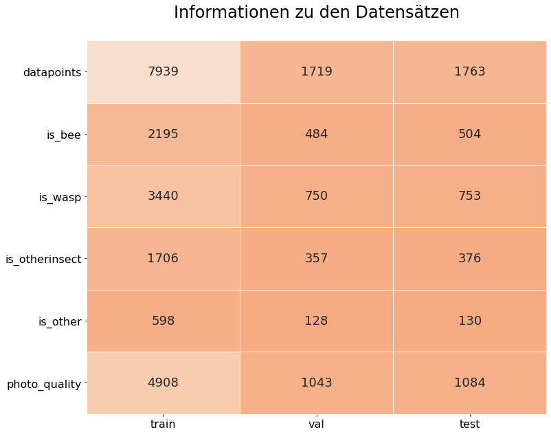

```python
plot_dataframe_info(df_label_train, df_label_val, df_label_test)
```

## Vorbereitung der Datengeneratoren

Die Daten in Form von Bildern werden rescaled mit einem Faktor von 1/255. Damit befinden sich die Werte zwischen Null und Eins.

Für den Testdatengenerator wird das shufflen auf False gesetzt, um am Ende die Vorhersagen mit den wahren Werten zu vergleichen.

```python
datagenerator = tf.keras.preprocessing.image.ImageDataGenerator(rescale=1./255.)

train_datagenerator = datagenerator.flow_from_dataframe(df_label_train,
                                                directory=dir_path,
                                                shuffle=True,
                                                x_col='path',
                                                y_col='label',
                                                seed=seed,
                                                class_mode='categorical',
                                                batch_size=batch_size,
                                                color_mode=color_mode,
                                                target_size=img_size
                                               )

valid_datagenerator = datagenerator.flow_from_dataframe(df_label_val,
                                                directory=dir_path,
                                                shuffle=True,
                                                x_col='path',
                                                y_col='label',
                                                seed=seed,
                                                class_mode='categorical',
                                                batch_size=batch_size,
                                                color_mode=color_mode,
                                                target_size=img_size
                                               )

test_datagenerator = datagenerator.flow_from_dataframe(df_label_test,
                                               directory=dir_path,
                                               shuffle=False,
                                               x_col='path',
                                               y_col='label',
                                               seed=seed,
                                               class_mode='categorical',
                                               batch_size=batch_size,
                                               color_mode=color_mode,
                                               target_size=img_size
                                               )
```

```
Found 7939 validated image filenames belonging to 4 classes.
Found 1719 validated image filenames belonging to 4 classes.
Found 1763 validated image filenames belonging to 4 classes.
```

## Train Models

### VGG-16

VGG-16 ist ein Convolutional Network, welches auf das imagenet vortrainiert wurde. Dieses Modell erzielt auf den ImageNet-Datensatz eine Genauigkeit von 92.7%.

Quelle: https://neurohive.io/en/popular-networks/vgg16/

Als Ausgabe werden 4 Ausgabeneuronen mit der Softmax Aktivierungsfunktion verwendet. Als Optimizer wird der Adam gewählt.

```python
feature_extractor = tf.keras.applications.VGG16(input_shape=input_shape,
                                                include_top=False,
                                                weights='imagenet')

model = tf.keras.Sequential([
  feature_extractor,
  tf.keras.layers.GlobalAveragePooling2D(),
  tf.keras.layers.Dense(4, activation='softmax')
])

model.compile(optimizer=tf.keras.optimizers.Adam(lr=0.00001),
              loss='binary_crossentropy',
              metrics=['accuracy'])

model.summary()
```

```
WARNING:tensorflow:From D:\Users\mario\anaconda3\envs\tfg1\lib\site-packages\tensorflow_core\python\ops\resource_variable_ops.py:1630: calling BaseResourceVariable.__init__ (from tensorflow.python.ops.resource_variable_ops) with constraint is deprecated and will be removed in a future version.
Instructions for updating:
If using Keras pass *_constraint arguments to layers.
Model: "sequential"
_________________________________________________________________
Layer (type)                 Output Shape              Param #
=================================================================
vgg16 (Model)                (None, 2, 2, 512)         14714688
_________________________________________________________________
global_average_pooling2d (Gl (None, 512)               0
_________________________________________________________________
dense (Dense)                (None, 4)                 2052
=================================================================
Total params: 14,716,740
Trainable params: 14,716,740
Non-trainable params: 0
_________________________________________________________________
```

```python
steps_per_epoch = train_datagenerator.n // batch_size
validation_steps = valid_datagenerator.n // batch_size

callback = tf.keras.callbacks.EarlyStopping(monitor='val_acc', patience=patience, restore_best_weights=True)

history = model.fit_generator(train_datagenerator,
                              steps_per_epoch = steps_per_epoch,
                              epochs=epochs,
                              validation_data=valid_datagenerator,
                              validation_steps=validation_steps,
                              callbacks=[callback])
```

```
WARNING:tensorflow:From D:\Users\mario\anaconda3\envs\tfg1\lib\site-packages\tensorflow_core\python\ops\math_grad.py:1424: where (from tensorflow.python.ops.array_ops) is deprecated and will be removed in a future version.
Instructions for updating:
Use tf.where in 2.0, which has the same broadcast rule as np.where
```

Das Modell kommt bereits nach wenigen Epochen auf eine sehr hohe Genauigkeit. Als bestes Modell wird das Modell mit der höchsten Genauigkeit gewählt.

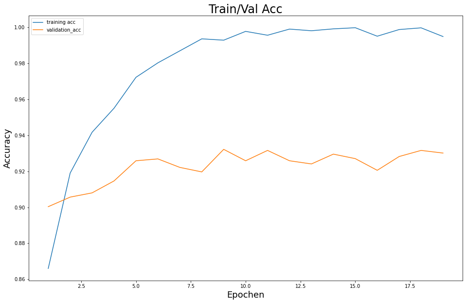

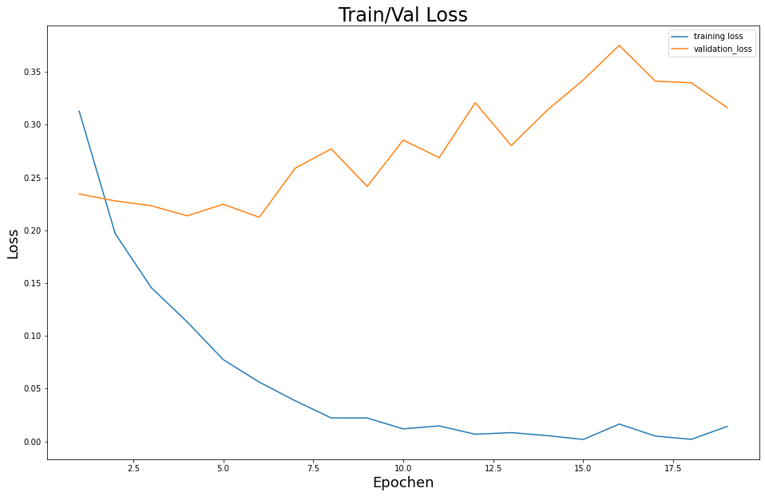

```python
plot_train_results(history)
```

#### Abspeichern des besten Modells

```python
model.save('models/vgg16_model.h5', save_format=".h5")
```

### ResNet-50

Residual Neural Networks sind Artifical Neural Networks welche eingebaute Sprünge über Layer beinhalten (sogenannte Shortcuts). Das Überspringen von Layern helfen, um das Vanishing Gradient Problem zu verhindern. Außerdem reduziert das Überspringen die Trainingsdauer und es ist möglich größere Netze zu bauen. Das hier verwendete ResNet-50 ist eine Variante mit 50 Layern.

https://en.wikipedia.org/wiki/Residual_neural_network https://towardsdatascience.com/an-overview-of-resnet-and-its-variants-5281e2f56035

```python
feature_extractor = tf.keras.applications.ResNet50(input_shape=input_shape,
                                                include_top=False,
                                                weights='imagenet')

model = tf.keras.Sequential([
  feature_extractor,
  tf.keras.layers.GlobalAveragePooling2D(),
  tf.keras.layers.Dense(4, activation='softmax')
])

model.compile(optimizer=tf.keras.optimizers.RMSprop(lr=2e-5),
              loss='binary_crossentropy',
              metrics=['accuracy'])

model.summary()
```

```
Model: "sequential_1"
_________________________________________________________________
Layer (type)                 Output Shape              Param #
=================================================================
resnet50 (Model)             (None, 2, 2, 2048)        23587712
_________________________________________________________________
global_average_pooling2d_1 ( (None, 2048)              0
_________________________________________________________________
dense_1 (Dense)              (None, 4)                 8196
=================================================================
Total params: 23,595,908
Trainable params: 23,542,788
Non-trainable params: 53,120
_________________________________________________________________
```

```python
steps_per_epoch = train_datagenerator.n // batch_size
validation_steps = valid_datagenerator.n // batch_size

callback = tf.keras.callbacks.EarlyStopping(monitor='val_acc', patience=patience, restore_best_weights=True)

history = model.fit_generator(train_datagenerator,
                              steps_per_epoch = steps_per_epoch,
                              epochs=epochs,
                              validation_data=valid_datagenerator,
                              validation_steps=validation_steps,
                              callbacks=[callback])
```

Das Modell kommt bereits nach wenigen Epochen auf eine sehr hohe Genauigkeit. Als bestes Modell wird das Modell mit der höchsten Genauigkeit gewählt.

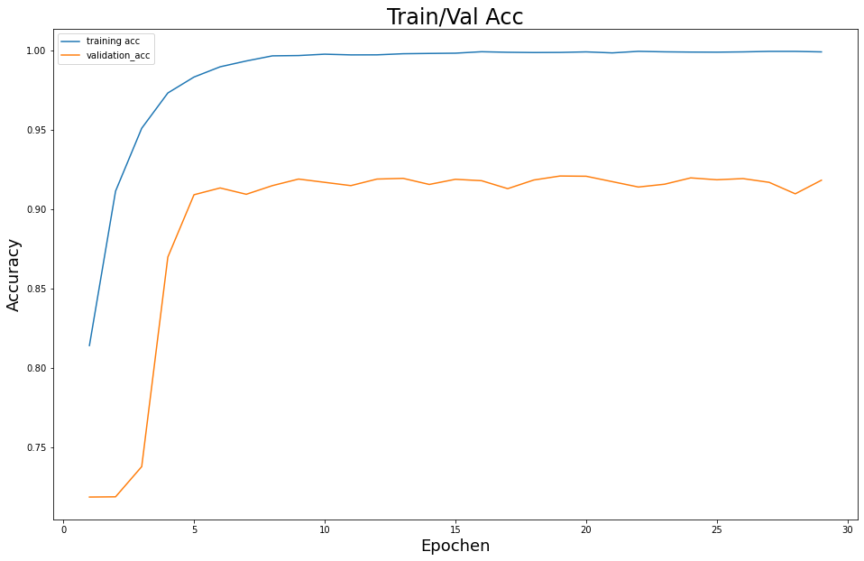

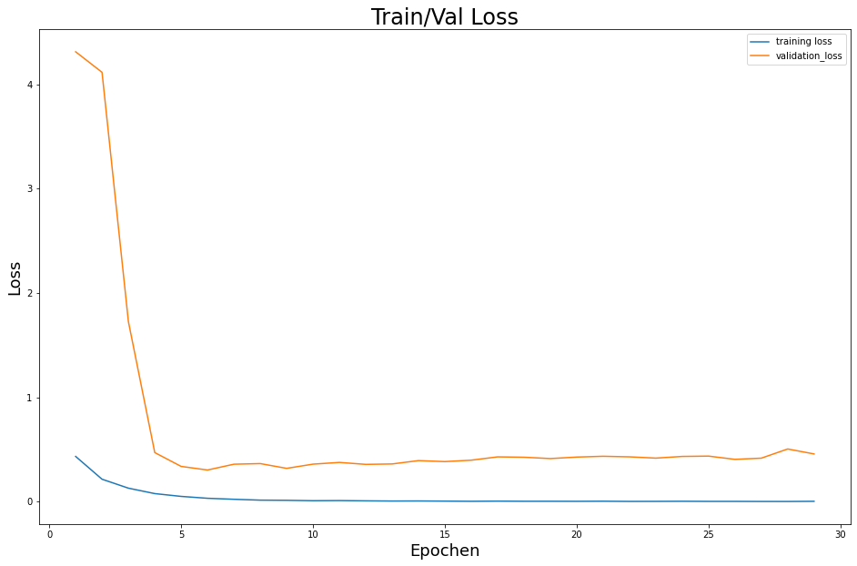

```python
plot_train_results(history)
```

#### Abspeichern des besten Modells

```python
model.save('models/resnet50_model.h5', save_format=".h5")
```

### Fully Convolutional Neural Network

Fully Convolutional Networks sind Netze, welche ausschließlich aus den Convolution-Layern bestehen und deren Größe unverändert bleiben. Eine weitere Charakteristik ist ein finaler Global Pooling Layer, welcher die Parameter drastisch reduziert und das Nutzen einer Class-Activation-Map (CAM) ermöglicht. CAM bietet die Möglichkeit die Eingabeneuronen, welche die meiste Auswirkungen auf die Vorhersage eines Datenpunktes hatten, hervorzuheben.

https://link.springer.com/article/10.1007/s10618-019-00619-1

```python
def create_FCN(input_shape):
    inp = tf.keras.layers.Input(shape=input_shape)

    conv2d = tf.keras.layers.Conv2D(filters=64, kernel_size=(3,3), strides=1, padding="same")(inp)
    conv2d = tf.keras.layers.Conv2D(filters=64, kernel_size=(3,3), strides=1, padding="same")(conv2d)
    conv2d = tf.keras.layers.Conv2D(filters=32, kernel_size=(3,3), strides=1, padding="same")(conv2d)
    conv2d = tf.keras.layers.Conv2D(filters=32, kernel_size=(3,3), strides=1, padding="same")(conv2d)

    globpool = tf.keras.layers.GlobalMaxPooling2D()(conv2d)

    out = tf.keras.layers.Dense(4, activation='softmax')(globpool)

    model = tf.keras.Model(inputs=inp, outputs=out)
    return model
```

```python
model = create_FCN(input_shape)

model.compile(optimizer=tf.keras.optimizers.Adam(lr=0.001),
              loss='binary_crossentropy',
              metrics=['accuracy'])

model.summary()
```

```
Model: "model"
_________________________________________________________________
Layer (type)                 Output Shape              Param #
=================================================================
input_3 (InputLayer)         [(None, 64, 64, 3)]       0
_________________________________________________________________
conv2d (Conv2D)              (None, 64, 64, 64)        1792
_________________________________________________________________
conv2d_1 (Conv2D)            (None, 64, 64, 64)        36928
_________________________________________________________________
conv2d_2 (Conv2D)            (None, 64, 64, 32)        18464
_________________________________________________________________
conv2d_3 (Conv2D)            (None, 64, 64, 32)        9248
_________________________________________________________________
global_max_pooling2d (Global (None, 32)                0
_________________________________________________________________
dense_2 (Dense)              (None, 4)                 132
=================================================================
Total params: 66,564
Trainable params: 66,564
Non-trainable params: 0
_________________________________________________________________
```

```python
steps_per_epoch = train_datagenerator.n // batch_size
validation_steps = valid_datagenerator.n // batch_size

callback = tf.keras.callbacks.EarlyStopping(monitor='val_acc', patience=patience, restore_best_weights=True)

history = model.fit_generator(train_datagenerator,
                              steps_per_epoch = steps_per_epoch,
                              epochs=epochs,
                              validation_data=valid_datagenerator,
                              validation_steps=validation_steps,
                              callbacks=[callback])
```

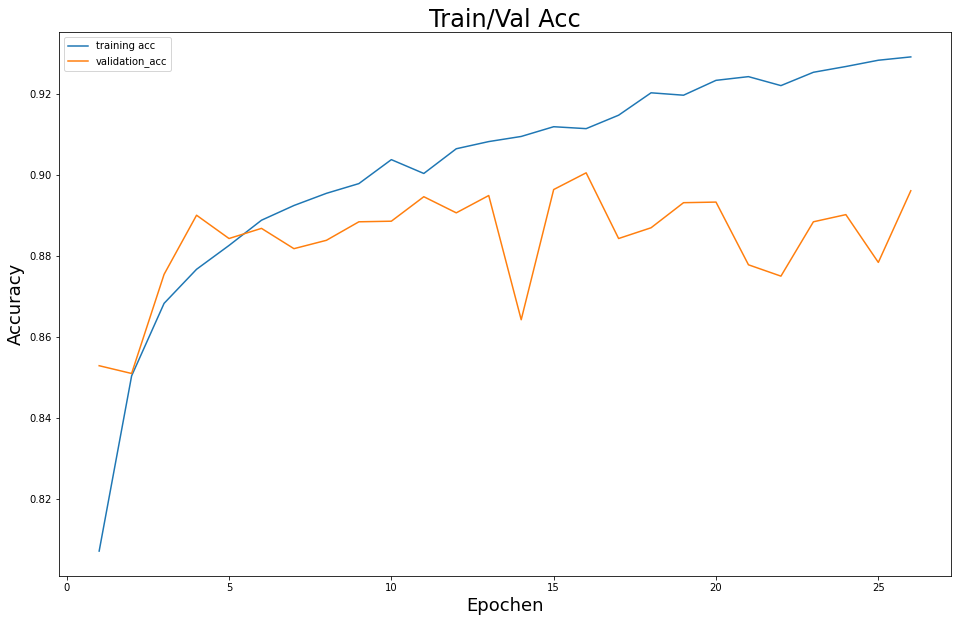

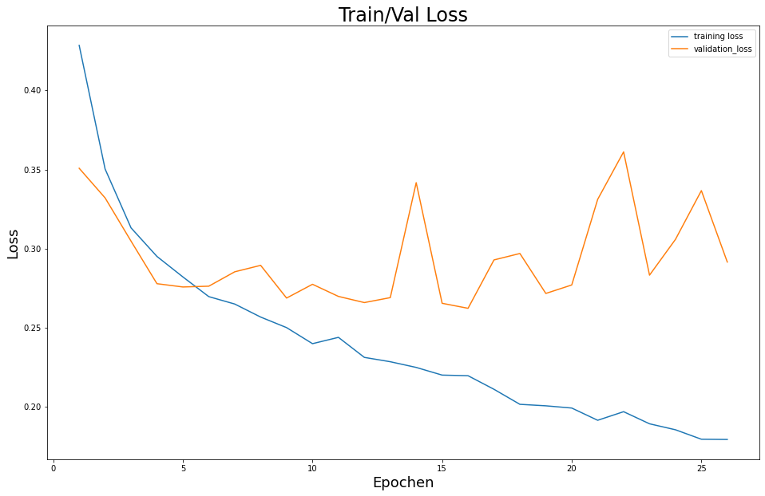

```python
plot_train_results(history)
```

#### Abspeichern des besten Modells

```python
model.save('models/fcn_model.h5', save_format=".h5")
```

## Testen und Vergleich der Modelle auf den Testdatensatz

```python
fcn_model = tf.keras.models.load_model('models/fcn_model.h5')
resnet50_model = tf.keras.models.load_model('models/resnet50_model.h5')
vgg16_model = tf.keras.models.load_model('models/vgg16_model.h5')
```

[output not shown]

```python
fcn_results = fcn_model.predict_generator(test_datagenerator)
resnet50_results = resnet50_model.predict_generator(test_datagenerator)
vgg16_results = vgg16_model.predict_generator(test_datagenerator)

y_true = test_datagenerator.classes

plot_labels = list(test_datagenerator.class_indices.keys())
```

```python
fcn_accuracy = fcn_model.evaluate_generator(test_datagenerator)
resnet50_accuracy = resnet50_model.evaluate_generator(test_datagenerator)
vgg16_accuracy = vgg16_model.evaluate_generator(test_datagenerator)
```

## Ergebnisse

Grundsätzlich erzielen alle Modelle gute Ergebnisse.

- 92.81% VGG16
- 92.14% ResNet50
- 88.94% FCN

```python
print("Accuracy des FCN: ", fcn_accuracy[1])
print("Accuracy des VGG16: ", vgg16_accuracy[1])
print("Accuracy des ResNet50: ", resnet50_accuracy[1])
```

```
Accuracy des FCN:  0.8893931
Accuracy des VGG16:  0.9281055
Accuracy des ResNet50:  0.9214407
```

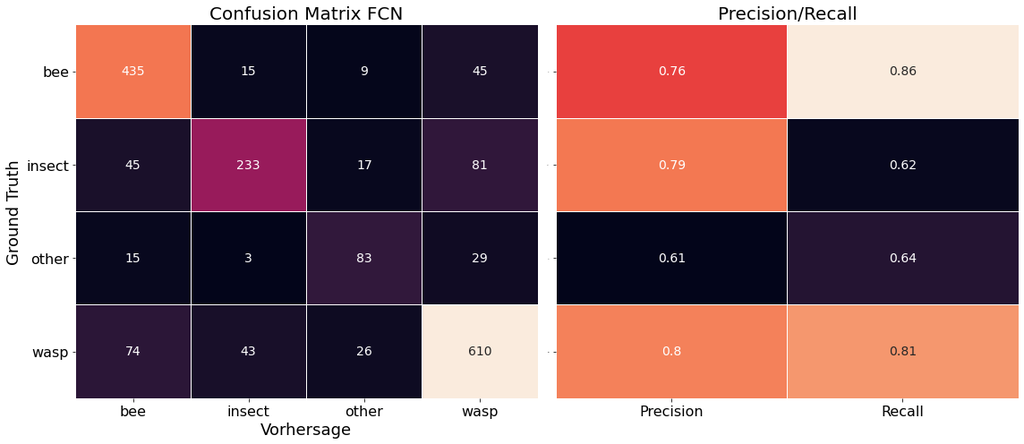

```python
plot_results(y_true, fcn_results, "FCN", plot_labels)
```

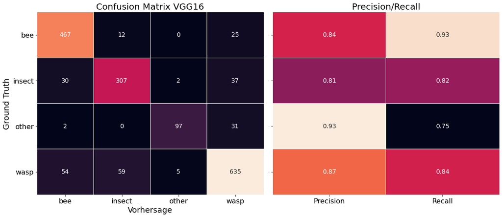

```python
plot_results(y_true, vgg16_results, "VGG16", plot_labels)
```

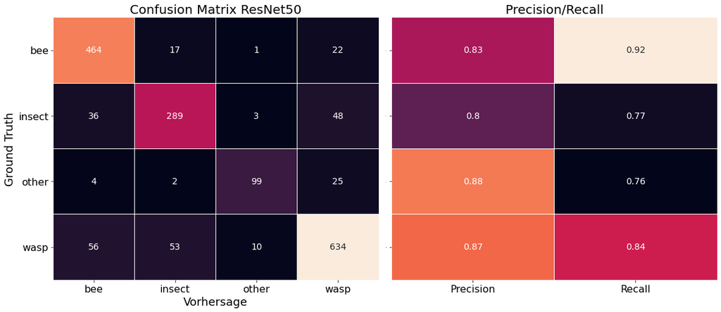

```python
plot_results(y_true, resnet50_results, "ResNet50", plot_labels)
```

## Class Activation Mapping mit dem Fully Convolutional Neural Network

Im folgenden sieht man ein paar Bienenvorhersagen. Im Kaggleforum wurde darauf aufmerksam gemacht, dass darauf geachtet werden sollte, dass Bienen nicht anhand Blumen vorhergesagt werden. Das CAM zeigt hierbei, dass die Vorhersage anhand der Region der Biene gemacht wurde.

Darunter wurden noch zwei Mal Wespen vorhergesagt, wobei es sich bei einer um eine falsche Vorhersage handelt.

```
Vorhersage:  bee
```

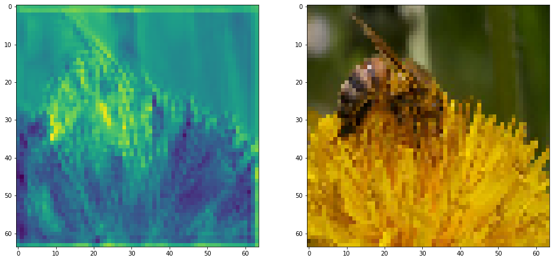

```
Vorhersage:  bee
```

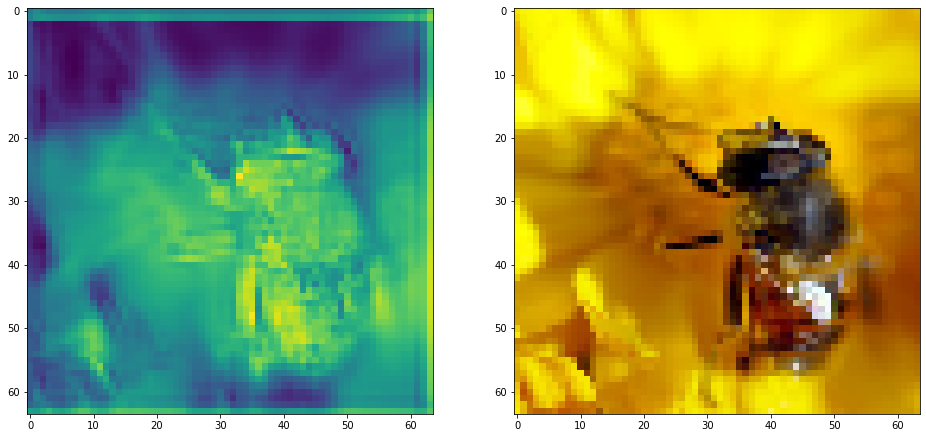

```python
data = test_datagenerator.next()
visualize_class_activation_map(fcn_model, data, plot_labels)
```

```
Vorhersage:  bee
```

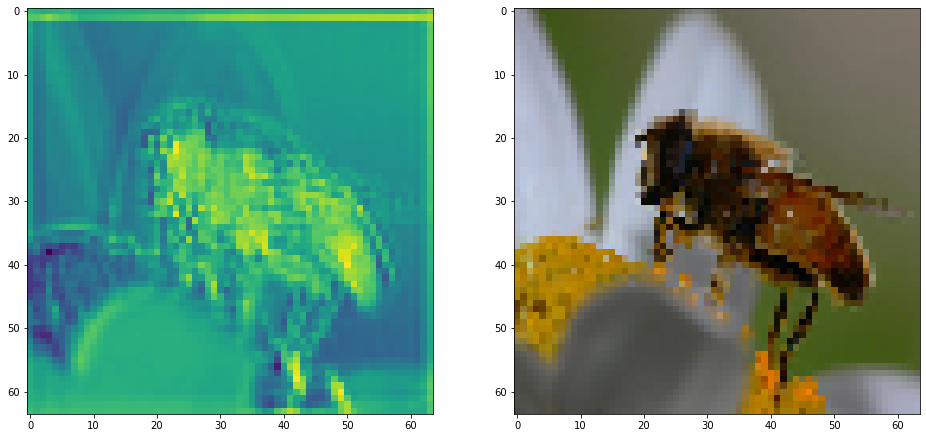

```
Vorhersage:  insect
```

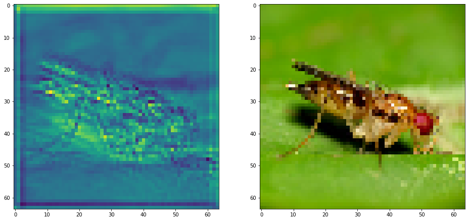

```python
data = test_datagenerator.next()
visualize_class_activation_map(fcn_model, data, plot_labels)
```

```
Vorhersage:  wasp
```

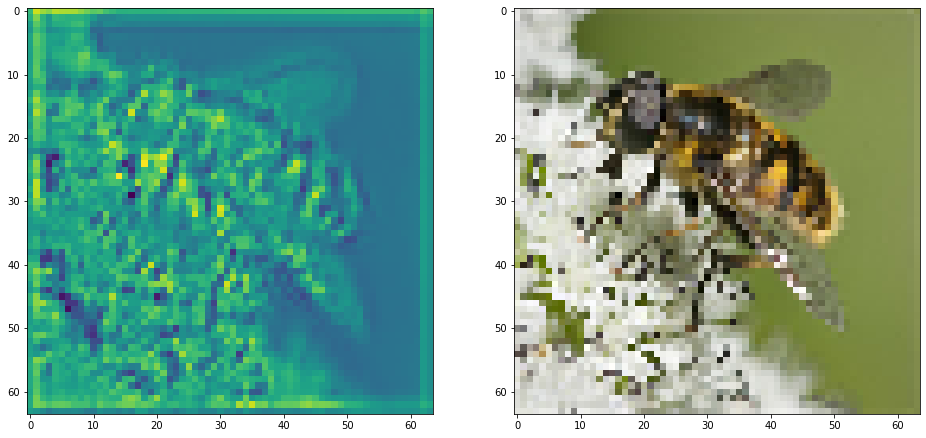

```
Vorhersage:  wasp
```

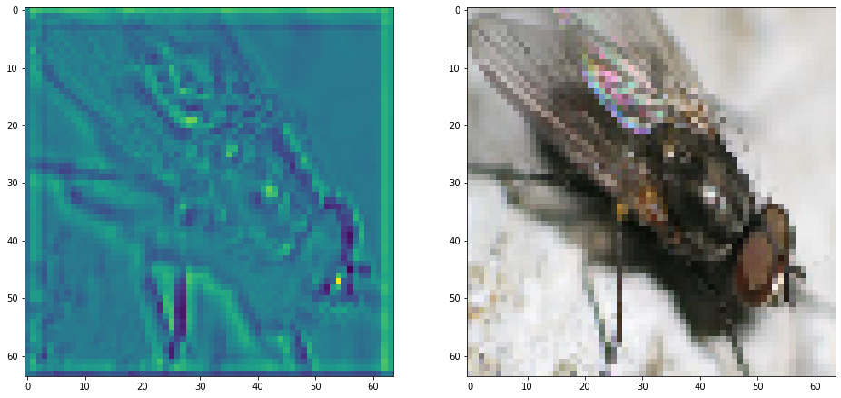

```python
data = test_datagenerator.next()
visualize_class_activation_map(fcn_model, data, plot_labels)
```

## Zusätzliche Quellen/Inspiration:

#### Datensatz:

- https://www.kaggle.com/jerzydziewierz/bee-vs-wasp

#### Zum Datensatz zugehörige code-examples:

##### ResNet Bees vs Wasps example:

- https://www.kaggle.com/thienbuu9/bee-vs-wasp-cnn-scratch-to-tranfer-learning-94

#### Early Stopping:

- https://www.tensorflow.org/api_docs/python/tf/keras/callbacks/EarlyStopping
- https://machinelearningmastery.com/how-to-stop-training-deep-neural-networks-at-the-right-time-using-early-stopping/

#### VGG-Example

- Übung ADL_03_Tutorial_Schutera

#### ResNet-50 Example

- https://towardsdatascience.com/deep-learning-using-transfer-learning-python-code-for-resnet50-8acdfb3a2d38

#### Multiclass Classification example

- https://machinelearningmastery.com/multi-class-classification-tutorial-keras-deep-learning-library/

#### CAM

- https://jacobgil.github.io/deeplearning/class-activation-maps
- https://gist.github.com/patrickbrus/241c26190cc28e39723514e2c2c1b2e6
- https://towardsdatascience.com/class-activation-mapping-using-transfer-learning-of-resnet50-e8ca7cfd657e
- https://towardsdatascience.com/demystifying-convolutional-neural-networks-using-class-activation-maps-fe94eda4cef1